# Poisoned texts report

[figure not shown]

**Reference**: Cabedo, A. (2022) Poisoned texts. V.1.0 beta. Available at: https://github.com/acabedo/poisonedtexts

GNU General Public License v3.0

In this report you will find tables and charts covering the selected texts. Please, take into account that the interpretation it has not only one direction, and that this is a task for a specialist.

# 1 Summary

In this section, there are two brief summaries. The first one shows the number of paragraphs, sentences and ngrams for each text file. The second one presents the quantity of ngrams shared more than once, just once between at least two files or even ngrams appearing only at one of the texts being analysed.

The selected ngrams for the analysis were 5.

## 1.1 Basic info

| filename | paragraphs | sentences | words |
| --- | --- | --- | --- |
| estegosaurio.txt | 1 | 19 | 600 |
| spinosaurio.txt | 1 | 21 | 683 |
| tiranosaurio.txt | 1 | 15 | 422 |

## 1.2 Shared or genuine lexical items

| ngram | type | freq | total |
| --- | --- | --- | --- |
| estegosaurio.txt | once | 1 | 0.23 |
| estegosaurio.txt | only | 441 | 99.77 |
| spinosaurio.txt | once | 4 | 0.76 |
| spinosaurio.txt | only | 522 | 99.24 |
| tiranosaurio.txt | once | 5 | 1.61 |
| tiranosaurio.txt | only | 306 | 98.39 |

## 1.3 File by file coincidence

| filename | variable | value | total | percent |
| --- | --- | --- | --- | --- |
| tiranosaurio.txt | spinosaurio.txt | 4 | 311 | 1.29 |
| spinosaurio.txt | tiranosaurio.txt | 4 | 526 | 0.76 |
| tiranosaurio.txt | estegosaurio.txt | 1 | 311 | 0.32 |
| estegosaurio.txt | tiranosaurio.txt | 1 | 442 | 0.23 |
| estegosaurio.txt | estegosaurio.txt | 0 | 442 | 0.00 |
| spinosaurio.txt | estegosaurio.txt | 0 | 526 | 0.00 |
| estegosaurio.txt | spinosaurio.txt | 0 | 442 | 0.00 |
| spinosaurio.txt | spinosaurio.txt | 0 | 526 | 0.00 |
| tiranosaurio.txt | tiranosaurio.txt | 0 | 311 | 0.00 |

# 2 Style

This section covers several variables covering common styling characteristics for individuals. These variables must be selected previously on the app. Accordingly, they will be projected on a heatmap.

The frequencies have been automatically scaled with a reference to 100 words, because every sentence has a different quantity of words. Furthermore, the variable *words* refers to the mean of words by sentence for every text.

| doc_id | words | qnoun | qpropn | qcconj | qadv | qprep | qadj | qverb | qdet | qcomma | qcolon |
| --- | --- | --- | --- | --- | --- | --- | --- | --- | --- | --- | --- |
| estegosaurio.txt | 31.6 | 19.1 | 8.5 | 4.4 | 5.4 | 14.3 | 7.9 | 6.2 | 12.1 | 5.5 | 0.0 |
| spinosaurio.txt | 32.5 | 19.3 | 6.2 | 5.1 | 2.6 | 13.1 | 8.9 | 8.9 | 11.9 | 4.2 | 0.9 |
| tiranosaurio.txt | 28.1 | 17.8 | 4.6 | 3.9 | 4.4 | 15.0 | 8.9 | 6.0 | 13.5 | 3.6 | 0.1 |

## 2.1 Heatmap

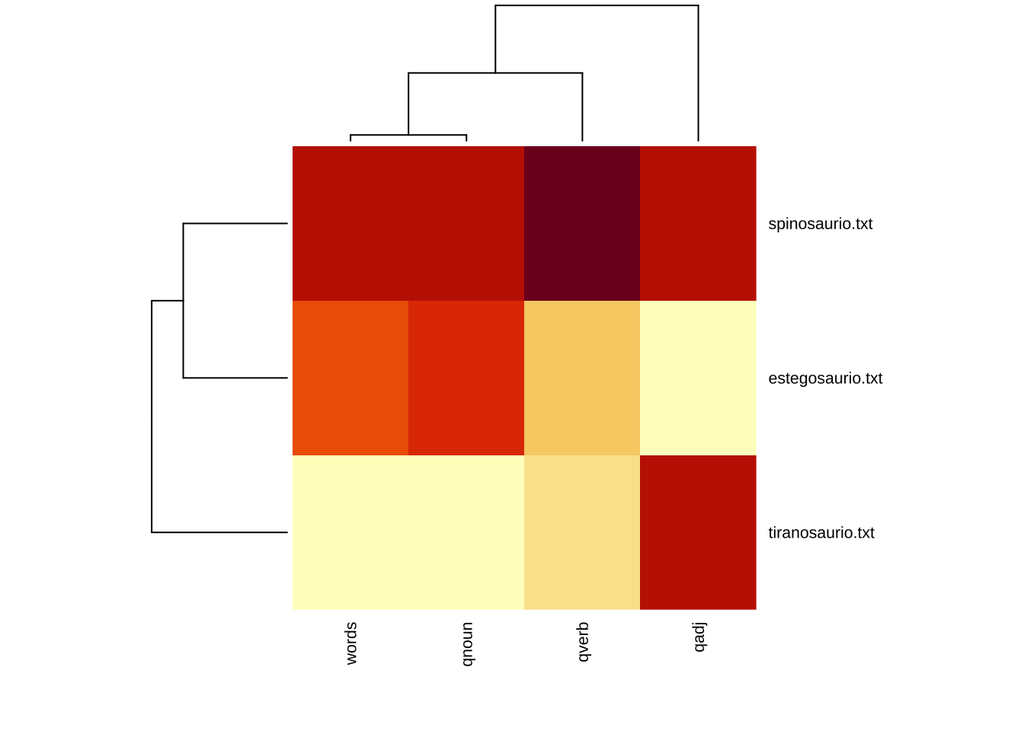

## 2.2 Most frequent words

[output not shown]

## 2.3 Most frequent words first position in sentence

### 2.3.1 Single words

| doc_id | token | freq |
| --- | --- | --- |
| estegosaurio.txt | Stegosaurus | 4 |
| estegosaurio.txt | A | 2 |
| spinosaurio.txt | La | 3 |
| spinosaurio.txt | El | 2 |
| tiranosaurio.txt | Su | 2 |
| tiranosaurio.txt | Aunque | 1 |

### 2.3.2 Two first words

| doc_id | ngram | freq |
| --- | --- | --- |
| estegosaurio.txt | Debido a | 2 |
| estegosaurio.txt | A el | 1 |
| spinosaurio.txt | Los huesos | 2 |
| spinosaurio.txt | A esta | 1 |
| tiranosaurio.txt | Aunque otros | 1 |
| tiranosaurio.txt | Como otros | 1 |

### 2.3.3 Three first words

| doc_id | ngram | freq |
| --- | --- | --- |
| estegosaurio.txt | A el menos | 1 |
| estegosaurio.txt | A pesar de | 1 |
| spinosaurio.txt | Los huesos de | 2 |
| spinosaurio.txt | A esta estructura | 1 |
| tiranosaurio.txt | Aunque otros terópodos | 1 |
| tiranosaurio.txt | Como otros tiranosáuridos | 1 |

### 2.3.4 Four first words

| doc_id | ngram | freq |
| --- | --- | --- |
| estegosaurio.txt | A el menos tres | 1 |
| estegosaurio.txt | A pesar de su | 1 |
| spinosaurio.txt | A esta estructura se | 1 |
| spinosaurio.txt | El cráneo del de | 1 |
| tiranosaurio.txt | Aunque otros terópodos rivalizan | 1 |
| tiranosaurio.txt | Como otros tiranosáuridos , | 1 |

## 2.4 Most frequent upos first position in sentence

### 2.4.1 Single upos

| doc_id | upos | freq |
| --- | --- | --- |
| estegosaurio.txt | PROPN | 5 |
| estegosaurio.txt | DET | 4 |
| spinosaurio.txt | DET | 11 |
| spinosaurio.txt | ADP | 2 |
| tiranosaurio.txt | DET | 7 |
| tiranosaurio.txt | ADP | 2 |

### 2.4.2 Two first upos

| doc_id | ngram | freq |
| --- | --- | --- |
| estegosaurio.txt | DET NOUN | 3 |
| estegosaurio.txt | ADP DET | 2 |
| spinosaurio.txt | DET NOUN | 10 |
| spinosaurio.txt | PRON VERB | 2 |
| tiranosaurio.txt | DET NOUN | 6 |
| tiranosaurio.txt | ADP DET | 1 |

### 2.4.3 Three first upos

| doc_id | ngram | freq |
| --- | --- | --- |
| estegosaurio.txt | DET NOUN ADP | 2 |
| estegosaurio.txt | VERB ADP DET | 2 |
| spinosaurio.txt | DET NOUN ADJ | 3 |
| spinosaurio.txt | DET NOUN ADP | 3 |
| tiranosaurio.txt | DET NOUN ADP | 4 |
| tiranosaurio.txt | ADP DET NOUN | 1 |

### 2.4.4 Four first upos

| doc_id | ngram | freq |
| --- | --- | --- |
| estegosaurio.txt | ADP DET ADV NUM | 1 |
| estegosaurio.txt | ADP DET NOUN SCONJ | 1 |
| spinosaurio.txt | DET NOUN ADP DET | 3 |
| spinosaurio.txt | DET NOUN VERB SCONJ | 2 |
| tiranosaurio.txt | DET NOUN ADP NOUN | 2 |
| tiranosaurio.txt | ADP DET NOUN PUNCT | 1 |

# 3 Similar sentences

This last section presents the common verbatim concordances for the coinciding *ngrams* among at least two texts.

| doc_id | sentence_id | ngram | total | sentence2 |
| --- | --- | --- | --- | --- |
| spinosaurio.txt | 1 | del período cretácico hace aproximadamente | 2 | Spinosaurus aegyptiacus es la única especie conocida del género extinto Spinosaurus gr «lagarto de espina» de dinosaurio terópodo espinosáurido que vivió a mediados del período cretácico hace aproxima… |
| tiranosaurio.txt | 1 | del período cretácico hace aproximadamente | 2 | Tyrannosaurus rex del griego latinizado tyrannus ‘tirano’ y saurus ‘lagarto’ y el latín rex ’rey’1 es la única especie conocida del género fósil Tyrannosaurus de dinosaurio terópodo tiranosáurido que… |
| spinosaurio.txt | 1 | es la única especie conocida | 2 | Spinosaurus aegyptiacus es la única especie conocida del género extinto Spinosaurus gr «lagarto de espina» de dinosaurio terópodo espinosáurido que vivió a mediados del período Cretácico hace aproxima… |
| tiranosaurio.txt | 1 | es la única especie conocida | 2 | Tyrannosaurus rex del griego latinizado tyrannus ‘tirano’ y saurus ‘lagarto’ y el latín rex ’rey’1 es la única especie conocida del género fósil Tyrannosaurus de dinosaurio terópodo tiranosáurido que… |
| estegosaurio.txt | 3 | es uno de los más | 2 | Debido a sus distintivas espinas de la cola y placas Stegosaurus es uno de los más reconocidos dinosaurios |
| tiranosaurio.txt | 9 | es uno de los más | 2 | El debate de si Tyrannosaurus fue un depredador dominante o un carroñero es uno de los más largos en la paleontología |
| spinosaurio.txt | 1 | la única especie conocida del | 2 | Spinosaurus aegyptiacus es la única especie conocida del género extinto Spinosaurus gr «lagarto de espina» de dinosaurio terópodo espinosáurido que vivió a mediados del período Cretácico hace aproxima… |
| tiranosaurio.txt | 1 | la única especie conocida del | 2 | Tyrannosaurus rex del griego latinizado tyrannus ‘tirano’ y saurus ‘lagarto’ y el latín rex ’rey’1 es la única especie conocida del género fósil Tyrannosaurus de dinosaurio terópodo tiranosáurido que… |
| estegosaurio.txt | 4 | se han encontrado restos de | 2 | Al menos tres especies han sido identificadas en la porción superior de la Formación Morrison del oeste de Estados Unidos y se han encontrado restos de por lo menos 80 individuos2 En 2006 se descubri… |
| estegosaurio.txt | 7 | se han encontrado restos de | 2 | se han encontrado restos de más de 80 individuos de este género |
| estegosaurio.txt | 3 | stegosaurus es uno de los | 3 | Debido a sus distintivas espinas de la cola y placas stegosaurus es uno de los más reconocidos dinosaurios |
| estegosaurio.txt | 10 | stegosaurus es uno de los | 3 | Debido a su combinación distintiva de placas anchas y verticales y cola con puntas en la punta stegosaurus es uno de los tipos de dinosaurios más reconocibles |
| estegosaurio.txt | 19 | stegosaurus es uno de los | 3 | stegosaurus es uno de los dinosaurios más conocidos y ha aparecido en películas sellos postales y muchos otros tipos de medios |
| spinosaurio.txt | 12 | una estructura similar a una | 2 | Las espinas neurales distintivas del Spinosaurus que eran largas extensiones de las vértebras crecían hasta al menos 165 metros de largo y probablemente tenían piel que las conectaba formando una estr… |
| spinosaurio.txt | 15 | una estructura similar a una | 2 | Su cola larga y estrecha estaba profundizada por espinas neurales altas y delgadas y cheurones alargados formando una aleta flexible o una estructura similar a una paleta |
| spinosaurio.txt | 1 | única especie conocida del género | 2 | Spinosaurus aegyptiacus es la única especie conocida del género extinto Spinosaurus gr «lagarto de espina» de dinosaurio terópodo espinosáurido que vivió a mediados del período Cretácico hace aproxima… |
| tiranosaurio.txt | 1 | única especie conocida del género | 2 | Tyrannosaurus rex del griego latinizado tyrannus ‘tirano’ y saurus ‘lagarto’ y el latín rex ’rey’1 es la única especie conocida del género fósil Tyrannosaurus de dinosaurio terópodo tiranosáurido que… |

# 4 Annex (texts)

In this section all the texts appear

| sentence_id |
| --- |
| estegosaurio.txt_1: Stegosaurus (gr. “lagarto con tejado” o “lagarto cubierto”1) es un género con 3, probablemente 4, especies conocidas de dinosaurios tireóforos estegosáuridos, que vivieron a final… |
| estegosaurio.txt_2: Coloquialmente en español llamado estegosaurio. |
| estegosaurio.txt_3: Debido a sus distintivas espinas de la cola y placas, Stegosaurus es uno de los más reconocidos dinosaurios. |
| estegosaurio.txt_4: Al menos tres especies han sido identificadas en la porción superior de la Formación Morrison, del oeste de Estados Unidos, y se han encontrado restos de por lo menos 80 individuos… |
| estegosaurio.txt_5: De las especies que se han clasificado en la Formación Morrison superior del oeste de los EE. |
| estegosaurio.txt_6: UU., solo tres son universalmente reconocidas, Stegosaurus stenops, Stegosaurus ungulatus y Stegosaurus sulcatus, con una cuarta Stegosaurus armatus siendo dudosa. |
| estegosaurio.txt_7: Se han encontrado restos de más de 80 individuos de este género. |
| estegosaurio.txt_8: Stegosaurus habría vivido junto a dinosaurios como Apatosaurus, Diplodocus , Brachiosaurus , Ceratosaurus, Allosaurus y Torvosaurus, siendo estos últimos sus posibles predadores. |
| estegosaurio.txt_9: Siendo un gran herbívoro cuadrúpedo, pesadamente constituido, Stegosaurus tenía una distintiva e inusual postura, con un lomo fuertemente arqueado, los miembros anteriores cortos, … |
| estegosaurio.txt_10: Debido a su combinación distintiva de placas anchas y verticales y cola con puntas en la punta, Stegosaurus es uno de los tipos de dinosaurios más reconocibles. |
| estegosaurio.txt_11: Su arsenal de placas y de púas ha sido el tema de muchas conjeturas. |
| estegosaurio.txt_12: Las espinas fueron utilizadas muy probablemente para la defensa, mientras que las placas también se han propuesto como mecanismo defensivo, y como parte de la exhibición y de las … |
| estegosaurio.txt_13: Stegosaurus tenía una proporción de masa cerebral a cuerpo relativamente baja. |
| estegosaurio.txt_14: Tenía un cuello corto y una cabeza pequeña, lo que significa que probablemente comía arbustos y plantas bajos. |
| estegosaurio.txt_15: Una de sus especies, Stegosaurus ungulatus, fue uno de los más grandes estegosaurianos, más grande que Kentrosaurus y que Huayangosaurus y aunque aproximadamente del tamaño de un … |
| estegosaurio.txt_16: Los restos de Stegosaurus fueron identificados por primera vez durante las “Guerras de los Huesos” por Othniel Charles Marsh en el Monumento Nacional Dinosaur Ridge. |
| estegosaurio.txt_17: Los primeros esqueletos conocidos eran fragmentarios y los huesos estaban dispersos, y pasarían muchos años antes de que se entendiera bien la verdadera apariencia de estos animal… |
| estegosaurio.txt_18: A pesar de su popularidad en libros y películas, los esqueletos montados de Stegosaurus no se convirtieron en un elemento básico de los principales museos de historia natural hast… |
| estegosaurio.txt_19: Stegosaurus es uno de los dinosaurios más conocidos y ha aparecido en películas, sellos postales y muchos otros tipos de medios. |
| spinosaurio.txt_1: Spinosaurus aegyptiacus es la única especie conocida del género extinto Spinosaurus (gr. «lagarto de espina») de dinosaurio terópodo espinosáurido, que vivió a mediados del período … |
| spinosaurio.txt_2: No existe claridad de si se trata de una o dos especies representadas por los fósiles reportados en la literatura científica. |
| spinosaurio.txt_3: La especie más conocida es S. aegyptiacus descubierta en Egipto; |
| spinosaurio.txt_4: sin embargo, una posible segunda especie S. maroccanus se descubrió en Marruecos. |
| spinosaurio.txt_5: También se han encontrado restos en Argelia, Túnez y posiblemente de Níger y Libia. |
| spinosaurio.txt_6: La mayoría de las últimas publicaciones consideran que la segunda especie e un sinónimo menor de la primera. |
| spinosaurio.txt_7: El género contemporáneo de espinosáuridos Sigilmassasaurus también ha sido sinonimizado por algunos autores con S. aegyptiacus, aunque otros investigadores proponen que sea un taxón… |
| spinosaurio.txt_8: Estimaciones publicadas en 2005, 2007 y 2008 sugieren que tenía 12,6 a 18 metros de longitud y 7 a 20,9 toneladas de peso.378 Nuevas estimaciones publicadas en 2014 y 2018, basad… |
| spinosaurio.txt_9: Las últimas estimaciones sugieren un peso de 6,4 a 7,5 toneladas.1011 |
| spinosaurio.txt_10: El cráneo del Spinosaurus era largo, bajo y angosto, similar al de un cocodrilo moderno y tenía dientes cónicos rectos sin estrías. |
| spinosaurio.txt_11: Habría tenido extremidades anteriores grandes y robustas con manos de tres dedos, con una garra agrandada en el primer dígito. |
| spinosaurio.txt_12: Las espinas neurales distintivas del Spinosaurus, que eran largas extensiones de las vértebras, crecían hasta al menos 1,65 metros de largo y probablemente tenían piel que las cone… |
| spinosaurio.txt_13: A esta estructura se le han atribuido múltiples funciones, incluyendo termorregulación y exhibición. |
| spinosaurio.txt_14: Los huesos de la cadera de Spinosaurus estaban reducidos y las piernas eran muy cortas en proporción al cuerpo. |
| spinosaurio.txt_15: Su cola larga y estrecha estaba profundizada por espinas neurales altas y delgadas y cheurones alargados , formando una aleta flexible o una estructura similar a una paleta. |
| spinosaurio.txt_16: Se cree que pudo haberse alimentado de pescado; |
| spinosaurio.txt_17: la evidencia sugiere que permanecía tanto en el agua como en tierra, como un cocodrilo moderno. |
| spinosaurio.txt_18: Se sabe que Spinosaurus comía pescado, y la mayoría de los científicos creen que cazaba presas tanto terrestres como acuáticas. |
| spinosaurio.txt_19: La evidencia sugiere que era altamente semiacuático y vivía tanto en la tierra como en el agua al igual que los cocodrilos modernos. |
| spinosaurio.txt_20: Los huesos de las piernas de Spinosaurus tenían osteosclerosis, alta densidad ósea, lo que permitía un mejor control de la flotabilidad y la cola en forma de paleta probablemente s… |
| spinosaurio.txt_21: Vivió en un ambiente húmedo de planicies intermareales y manglares y bosques junto con muchos otros dinosaurios, así como peces, crocodilomorfos, lagartos, tortugas, pterosaurios y… |
| tiranosaurio.txt_1: Tyrannosaurus rex (del griego latinizado tyrannus ‘tirano’ y saurus ‘lagarto’, y el latín rex, ‘rey’),1 es la única especie conocida del género fósil Tyrannosaurus de dinosaurio t… |
| tiranosaurio.txt_2: Su distribución en el continente fue mucho más amplia que otros tiranosáuridos. |
| tiranosaurio.txt_3: Comúnmente abreviado como T. rex, y castellanizado como tiranosaurio4 es una figura común en la cultura popular. |
| tiranosaurio.txt_4: Fue uno de los últimos dinosaurios no avianos que existieron antes de la extinción masiva del Cretácico-Terciario. |
| tiranosaurio.txt_5: Como otros tiranosáuridos, T. rex fue un carnívoro bípedo con un enorme cráneo equilibrado por una cola larga y pesada. |
| tiranosaurio.txt_6: En relación con sus largos y poderosos miembros traseros, los miembros superiores de Tyrannosaurus eran pequeños, pero sorprendentemente fuertes para su tamaño, y terminaban en dos… |
| tiranosaurio.txt_7: Aunque otros terópodos rivalizan o superan a Tyrannosaurus rex en tamaño, todavía es el mayor tiranosáurido conocido y uno de los mayores depredadores conocidos de la Tierra, midie… |
| tiranosaurio.txt_8: debió de haber sido el superpredador, cazando hadrosáuridos y ceratópsidos, aunque algunos expertos han sugerido que era principalmente carroñero. |
| tiranosaurio.txt_9: El debate de si Tyrannosaurus fue un depredador dominante o un carroñero es uno de los más largos en la paleontología. |
| tiranosaurio.txt_10: Hay más de 30 especímenes de Tyrannosaurus rex identificados, algunos de los cuales son esqueletos casi completos. |
| tiranosaurio.txt_11: Se han encontrado tejido conjuntivo y proteínas en por lo menos uno de estos especímenes. |
| tiranosaurio.txt_12: La abundancia de material fósil ha permitido investigar en detalle muchos aspectos de su biología, incluyendo su ciclo de vida y su biomecánica. |
| tiranosaurio.txt_13: Los hábitos de alimentación, la fisiología y la velocidad potencial de Tyrannosaurus rex son objeto de controversia. |
| tiranosaurio.txt_14: Su taxonomía es también polémica, con algunos científicos que consideran a Tarbosaurus bataar de Asia como una segunda especie de Tyrannosaurus mientras otros mantienen a Tarbosau… |
| tiranosaurio.txt_15: Varios otros géneros de tiranosáuridos norteamericanos también han sido sinonimizados a Tyrannosaurus. |